# R Notebook

**Principles of Data Visualization and Introduction to ggplot2**

I have provided you with data about the 5,000 fastest growing companies in the US, as compiled by Inc. magazine. lets read this in:

```r
inc <- read.csv("https://raw.githubusercontent.com/charleyferrari/CUNY_DATA_608/master/module1/Data/inc5000_data.csv", header= TRUE)
```

And lets preview this data:

```r
head(inc)
```

```
##   Rank                         Name Growth_Rate   Revenue
## 1    1                         Fuhu      421.48 1.179e+08
## 2    2        FederalConference.com      248.31 4.960e+07
## 3    3                The HCI Group      245.45 2.550e+07
## 4    4                      Bridger      233.08 1.900e+09
## 5    5                       DataXu      213.37 8.700e+07
## 6    6 MileStone Community Builders      179.38 4.570e+07
##                       Industry Employees         City State
## 1 Consumer Products & Services       104   El Segundo    CA
## 2          Government Services        51     Dumfries    VA
## 3                       Health       132 Jacksonville    FL
## 4                       Energy        50      Addison    TX
## 5      Advertising & Marketing       220       Boston    MA
## 6                  Real Estate        63       Austin    TX
```

```r
summary(inc)
```

```
##       Rank                          Name       Growth_Rate
##  Min.   :   1   (Add)ventures         :   1   Min.   :  0.340
##  1st Qu.:1252   @Properties           :   1   1st Qu.:  0.770
##  Median :2502   1-Stop Translation USA:   1   Median :  1.420
##  Mean   :2502   110 Consulting        :   1   Mean   :  4.612
##  3rd Qu.:3751   11thStreetCoffee.com  :   1   3rd Qu.:  3.290
##  Max.   :5000   123 Exteriors         :   1   Max.   :421.480
##                 (Other)               :4995
##     Revenue                                  Industry      Employees
##  Min.   :2.000e+06   IT Services                 : 733   Min.   :    1.0
##  1st Qu.:5.100e+06   Business Products & Services: 482   1st Qu.:   25.0
##  Median :1.090e+07   Advertising & Marketing     : 471   Median :   53.0
##  Mean   :4.822e+07   Health                      : 355   Mean   :  232.7
##  3rd Qu.:2.860e+07   Software                    : 342   3rd Qu.:  132.0
##  Max.   :1.010e+10   Financial Services          : 260   Max.   :66803.0
##                      (Other)                     :2358   NA's   :12
##             City          State
##  New York     : 160   CA     : 701
##  Chicago      :  90   TX     : 387
##  Austin       :  88   NY     : 311
##  Houston      :  76   VA     : 283
##  San Francisco:  75   FL     : 282
##  Atlanta      :  74   IL     : 273
##  (Other)      :4438   (Other):2764
```

Think a bit on what these summaries mean. Use the space below to add some more relevant non-visual exploratory information you think helps you understand this data:

```r
# Insert your code here, create more chunks as necessary
str(inc)
```

```
## 'data.frame':    5001 obs. of  8 variables:
##  $ Rank       : int  1 2 3 4 5 6 7 8 9 10 ...
##  $ Name       : Factor w/ 5001 levels "(Add)ventures",..: 1770 1633 4423 690 1198 2839 4733 1468 1869 4968 ...
##  $ Growth_Rate: num  421 248 245 233 213 ...
##  $ Revenue    : num  1.18e+08 4.96e+07 2.55e+07 1.90e+09 8.70e+07 ...
##  $ Industry   : Factor w/ 25 levels "Advertising & Marketing",..: 5 12 13 7 1 20 10 1 5 21 ...
##  $ Employees  : int  104 51 132 50 220 63 27 75 97 15 ...
##  $ City       : Factor w/ 1519 levels "Acton","Addison",..: 391 365 635 2 139 66 912 1179 131 1418 ...
##  $ State      : Factor w/ 52 levels "AK","AL","AR",..: 5 47 10 45 20 45 44 5 46 41 ...
```

str() function returns many useful pieces of information, We can find that there are 8 variables to measure the fastest growing companies. “Factor” in Str() means that variables are categorical variables. They are “Name”, “Industry”, “City”, and “State”. Numerical variables are: Rank (Integer), “Growth_Rate”, “Revenue”, “Employees”(Integer).

## Question 1

Create a graph that shows the distribution of companies in the dataset by State (ie how many are in each state). There are a lot of States, so consider which axis you should use. This visualization is ultimately going to be consumed on a ‘portrait’ oriented screen (ie taller than wide), which should further guide your layout choices.

```r
library(ggplot2)
library(dplyr)
# Answer Question 1 here

data_state <- inc %>% group_by(State) %>% tally()
data_state
```

```
## # A tibble: 52 x 2
##    State     n
##    <fct> <int>
##  1 AK        2
##  2 AL       51
##  3 AR        9
##  4 AZ      100
##  5 CA      701
##  6 CO      134
##  7 CT       50
##  8 DC       43
##  9 DE       16
## 10 FL      282
## # ... with 42 more rows
```

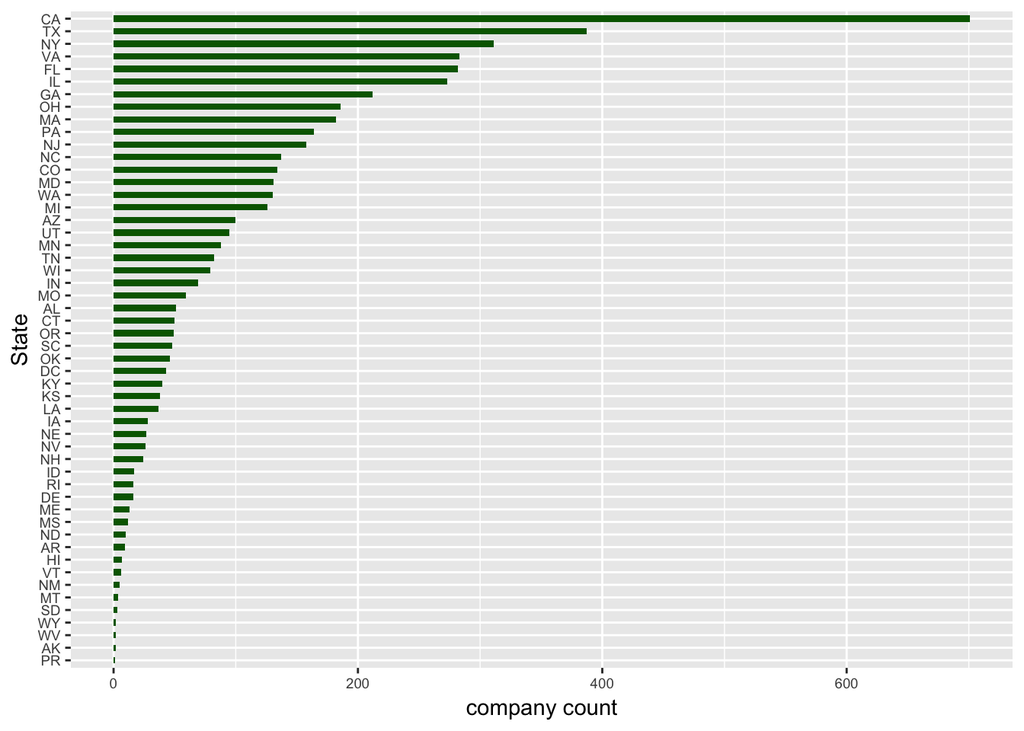

```r
ggplot(data_state, (aes(x=reorder(State, n), y= n))) +
         geom_bar(stat = "identity", fill = "darkgreen",width =0.5) + coord_flip()+
         theme(axis.text = element_text(size =7))+
         labs(x = "State", y= "company count")
```

```r
ggsave('Figure1.png')
```

## Quesiton 2

Lets dig in on the state with the 3rd most companies in the data set. Imagine you work for the state and are interested in how many people are employed by companies in different industries. Create a plot that shows the average and/or median employment by industry for companies in this state (only use cases with full data, use R’s `complete.cases()` function.) In addition to this, your graph should show how variable the ranges are, and you should deal with outliers.

```r
library(stringr)
# Answer Question 2 here
third_state <- inc %>% filter(str_detect(inc$State,"NY"))
head(third_state)
```

```
##   Rank                      Name Growth_Rate  Revenue
## 1   26              BeenVerified       84.43 13700000
## 2   30                  Sailthru       73.22  8100000
## 3   37              YellowHammer       67.40 18000000
## 4   38                 Conductor       67.02  7100000
## 5   48 Cinium Financial Services       53.65  5900000
## 6   70                  33Across       44.99 27900000
##                       Industry Employees      City State
## 1 Consumer Products & Services        17  New York    NY
## 2      Advertising & Marketing        79  New York    NY
## 3      Advertising & Marketing        27  New York    NY
## 4      Advertising & Marketing        89  New York    NY
## 5           Financial Services        32 Rock Hill    NY
## 6      Advertising & Marketing        75  New York    NY
```

```r
third_state <- third_state[complete.cases(third_state$Industry),]
third_state <- third_state[complete.cases(third_state$Employees),]
third_state <- arrange(third_state,desc(Employees))
head(third_state)
```

```
##   Rank                       Name Growth_Rate   Revenue
## 1 4577 Sutherland Global Services        0.48 5.976e+08
## 2 4936                       Coty        0.36 4.600e+09
## 3 4716              Westcon Group        0.44 3.800e+09
## 4 3899  Denihan Hospitality Group        0.71 2.808e+08
## 5 4363               TransPerfect        0.55 3.413e+08
## 6 1499       Sterling Infosystems        2.66 2.149e+08
##                       Industry Employees      City State
## 1 Business Products & Services     32000 Pittsford    NY
## 2 Consumer Products & Services     10000  New York    NY
## 3                  IT Services      3000 Tarrytown    NY
## 4         Travel & Hospitality      2280  New York    NY
## 5 Business Products & Services      2218  New York    NY
## 6              Human Resources      2081  New York    NY
```

```r
summary_stat<- summary(third_state$Employees)
summary_stat
```

```
##    Min. 1st Qu.  Median    Mean 3rd Qu.    Max.
##     1.0    21.0    45.0   271.3   105.5 32000.0
```

```r
IQR <- 105.5 - 21.0
Potential_Outlier <- 105.5 + 1.5 * IQR
Potential_Outlier
```

```
## [1] 232.25
```

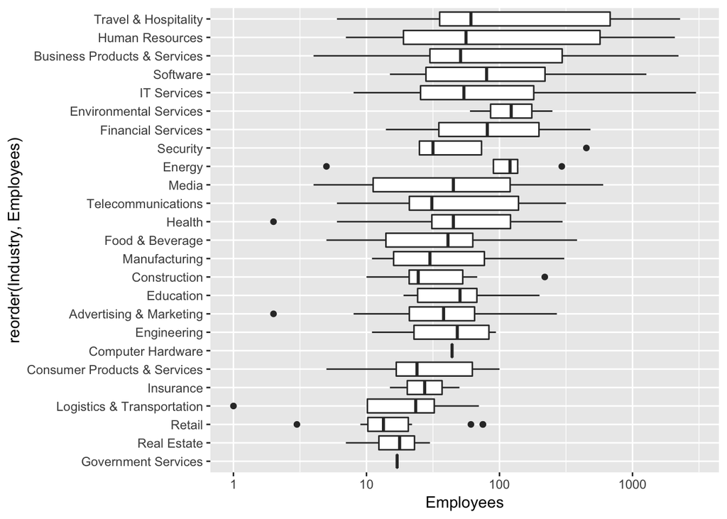

```r
third_state_noOutlier <- third_state %>% filter(Employees <= 3000)



ggplot(third_state_noOutlier,aes(x=reorder(Industry,Employees),y=Employees,mean))+geom_boxplot(show.legend = F)+
  coord_flip() + scale_y_log10()
```

```r
ggsave('Figure2.png')
```

## Question 3

Now imagine you work for an investor and want to see which industries generate the most revenue per employee. Create a chart that makes this information clear. Once again, the distribution per industry should be shown.

```r
# Answer Question 3 here

industryEmployee <- inc[complete.cases(inc),] %>% group_by(Industry) %>% summarise(TotRevenue = sum(Revenue), TotEmpl = sum(Employees)) %>% mutate(revPerEmpl = TotRevenue / TotEmpl)
industryEmployee
```

```
## # A tibble: 25 x 4
##    Industry                      TotRevenue TotEmpl revPerEmpl
##    <fct>                              <dbl>   <int>      <dbl>
##  1 Advertising & Marketing       7785000000   39731    195943.
##  2 Business Products & Services 26345900000  117357    224494.
##  3 Computer Hardware            11885700000    9714   1223564.
##  4 Construction                 13174300000   29099    452741.
##  5 Consumer Products & Services 14956400000   45464    328972.
##  6 Education                     1139300000    7685    148250.
##  7 Energy                       13771600000   26437    520921.
##  8 Engineering                   2532500000   20435    123930.
##  9 Environmental Services        2638800000   10155    259852.
## 10 Financial Services           13150900000   47693    275741.
## # ... with 15 more rows
```

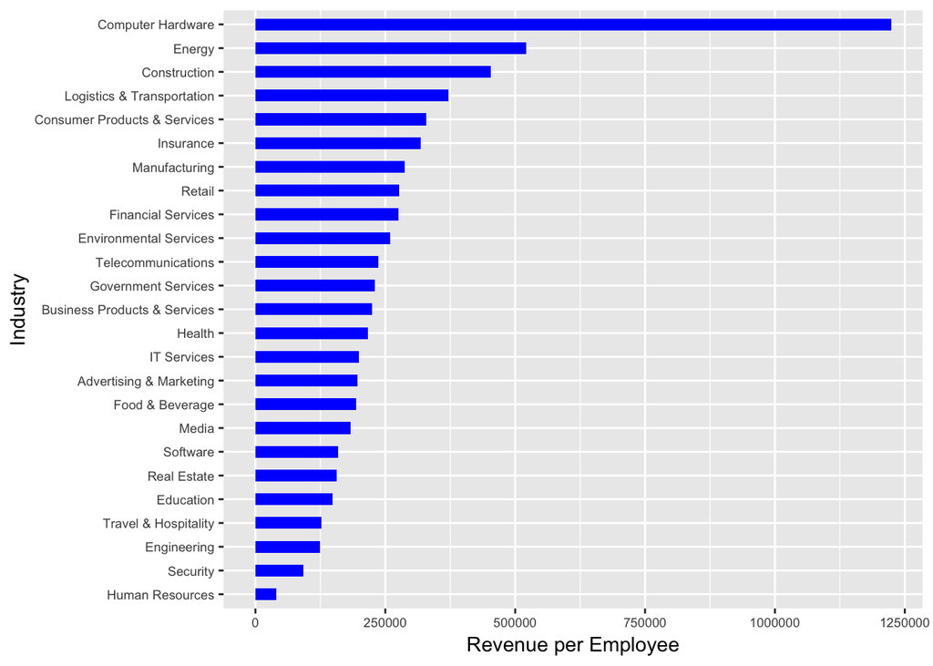

```r
ggplot(industryEmployee, (aes(x=reorder(Industry, revPerEmpl), y=revPerEmpl ))) +
         geom_bar(stat = "identity", fill = "blue",width =0.5) + coord_flip()+
         theme(axis.text = element_text(size =7))+
         labs(x = "Industry", y= "Revenue per Employee")
```

```r
ggsave('Figure3.png')
```